# Seminar 1 Introduction

Nicholas Sim

12 October 2023

# Administrative Matters

- Data visualization
  - Learn to use R/R Studio (optional class on Python)
  - Storytelling with data
- Main text is Data Visualization: A Practical Introduction by Kieran Healy
  - https://socviz.co (free access to book content)
- Other useful resources:
  - R for Data Science by Hadley Wickham (https://r4ds.had.co.nz/index.html)
  - RMarkdown: A Definitive Guide by Yihui Xie, J. J. Allaire, Garrett Grolemund (https://bookdown.org/yihui/rmarkdown/)
  - R Gallery Book by Kyle Brown (https://bookdown.org/content/b298e479-b1ab-49fa-b83d-a57c2b034d49/)
  - Storytelling with Data by Cole Nussbaumer-Knaflic (non-R)
- More advanced plotting
  - Interactive web-based data visualization with R, plotly, and shiny. (https://plotly-r.com/)

# Assessments

- Assessment
  - Pre-course Quiz 10%
  - Tutor-Marked Assignment (TMA) 30%
  - Participation 10%
  - End-of-course Assignment (ECA) 50%

# Submission

- Submission of assignments must be done via Canvas only.
- Please note that the datelines are **hard** (marks deduction will automatically be applied to late submissions).
- Please submit your assignment early if you are unable to submit on the dateline itself (e.g. travel for work).
- You must submit your assignment as a Word document. Submission of R/RMarkdown scripts only (without a Word document) will not be accepted.

# Attendence

- Attendance is compulsory.
- To receive SSG funding, you must achieve at least 75% attendance **AND** pass the course.

# Passing the Course

- You must **pass** both the OCAS (Overall Continuous Assessment Score) and the OES (Overall Examinable Score) components (i.e. $\ge 40\%$) to pass the course.
- If you do not submit the TMA,
  - but submit the ECA, you will receive an “F” grade automatically.
  - and do not submit the ECA, you will receive an “W” grade automatically.
- You **cannot pass the course** by submitting the ECA but not the TMA.

# What is Data Analytics?

Data analytics is the use of computing and statistical methods to generate information and insights from data.

These techniques may involve **data visualisation** or **machine learning**.

“Data visualization is the graphical representation of information and data” (www.tableau.com). It is usually the step prior to taking the data to machine learning models.

Machine learning is the use of computer algorithms and statistical theories to generate information, often for the purpose of predictions.

Machine learning techniques can broadly be classified into supervised learning, unsupervised learning, and reinforcement learning.

# What Will We Learn in ANL501?

- How to manage and clean data.
- Fundamental principles of data visualisation (Grammar of Graphics)
- A software (i.e. R) with the flexibility for highly customized data visualisations (for storytelling)

Note: We will not cover everything about R, but enough to the point that enable you to carry out more complex work with R.

# Course Structure - Seminars 1 to 3

- **Seminar 1**
  1. Introduction
  2. Basic R Operations
  3. R Programming

(Outside-of-class revision)

- **Seminar 2**
  1. Data Management in Base R
  2. Basic Statistics (for the purpose of interpretation and plotting)
  3. Principles of Data Storytelling and the Grammar of Graphics
- **Seminar 3**
  1. Getting Started with Data Visualisation
  2. A First Look at ggplot
  3. Aesthetics
  4. Settings
  5. More on Grammar of Graphics

# Course Structure - Seminars 4 to 6

- **Seminar 4**
  1. Introduction to RMarkdown
  2. Data Management with Tidyverse
  3. More Data Wrangling
  4. Time Series Plots, Bar Charts, Histograms and Densities
- **Seminar 5**
  1. Tables, Boxplots and Notes
  2. Choropleth Maps
  3. Spatial Visualisation with ggmap
- **Seminar 6**
  1. Storyboarding
  2. Suggested Practices in Data Storytelling
- **Optional Seminar**
  1. Python Programming and Seaborn

# Why R for Data Science/Visualisation?

Read: https://www.r-bloggers.com/2020/12/6-reasons-to-learn-r-for-business-2021/

1. Open Source.
2. Capability - A massive library of statistical packages.
3. Mates easily with other software, e.g. Python, SQL, etc.
4. Relatively easy to learn, particularly with the `tidyverse` library.
5. Reproducible reports, i.e. RMarkdown.
6. Highly flexible - interacts with Python (see documentation for the `reticulate` package https://rstudio.github.io/reticulate/)

# Why R for Data Science/Visualisation?

7. Data limitations, e.g. an Excel workbook can hold ~1 million records, but R (also Python) can hold ~ $2^{31} - 1$ records - difficult to work with large data in Excel.
8. Popular among data scientist

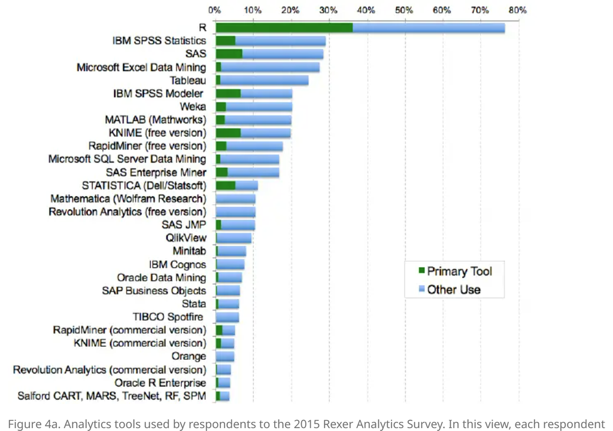

Source: https://r4stats.com/articles/popularity/

# Why Learn to Code?

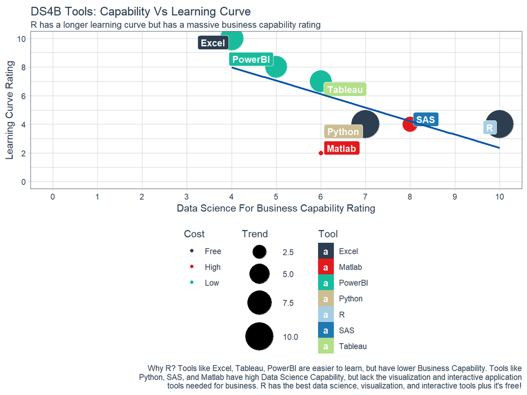

# Example - Scatter Plot

Seminar 3 (Scatter Plot with Color Aesthetics)

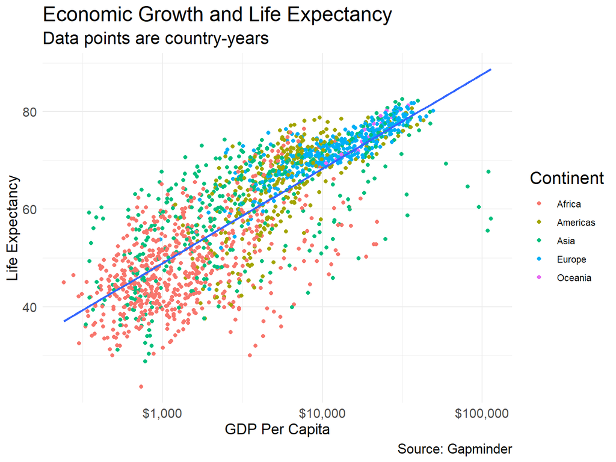

# Example - Animation

Seminar 3 (Animations)

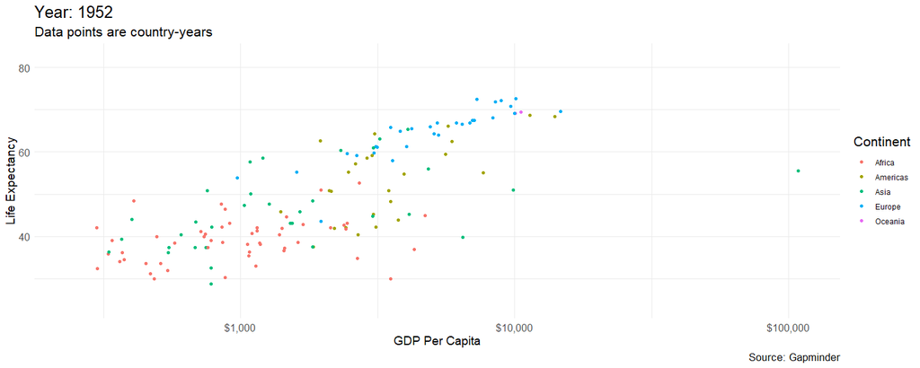

See, also, https://www.youtube.com/watch?v=SnCi0s0e4Io

# Example - Creating Facets

Seminar 4 (Line Plots with Facets)

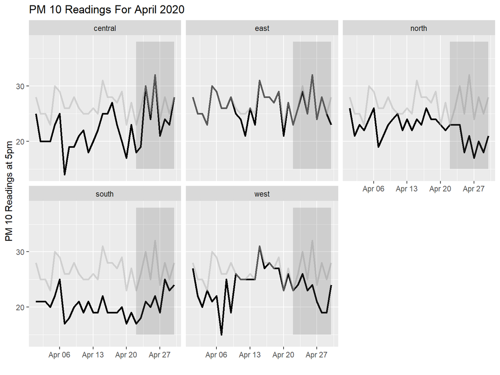

# Example - Boxplot with Flipped Coordinates

Seminar 5 (Flipped Boxplots)

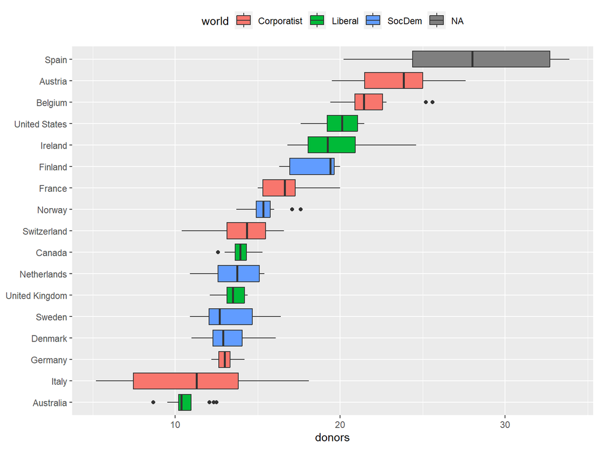

# Example - Visualising Spatial Data

Seminar 5 (Choropleth Map)

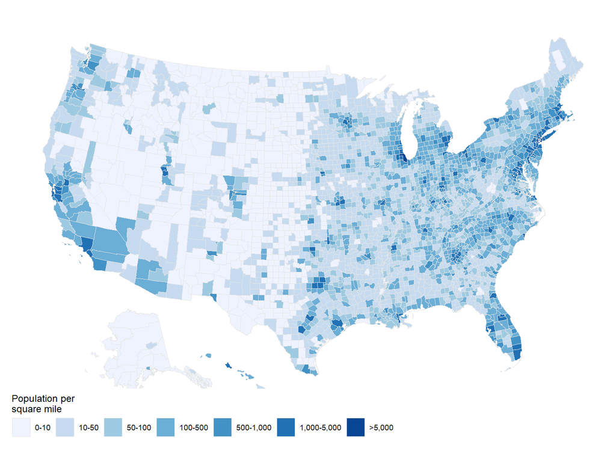

# Example - Using APIs

Seminar 5 (Google Maps)

[figure not shown]

# Example - Creating a Data Story

Seminar 6 (Storytelling)

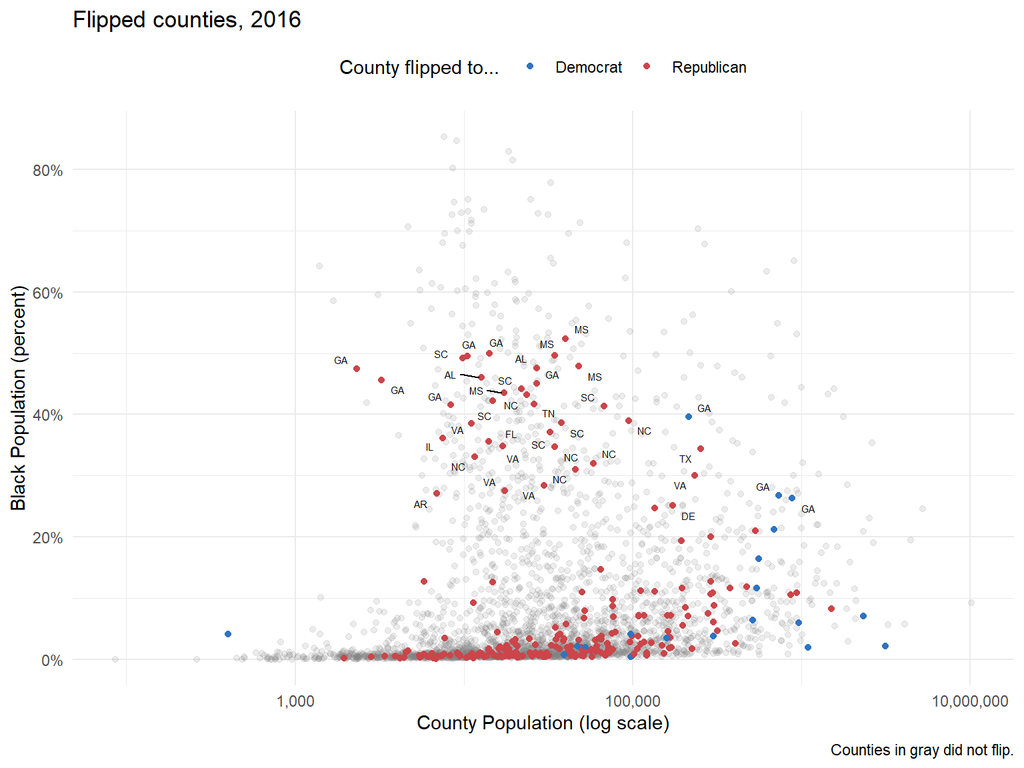

# Expectations

Hours Per Week:

1. Seminars (mandatory) - 3
2. Pre-class readings (slides) - 1
3. Post-class readings (slides and assigned text) and practice - 3
4. Assessments - 3
5. Others (e.g. Datacamp) - 0.5

# Slides Format

The slides are prepared using the “slidy” presentation format from RMarkdown. As an html format, slidy enables dynamic visualisations (say, animated visualisations and dynamic maps) to be displayed on the slides.

Other html presentation formats are ioslides and reveal.js. Although they are more visually appealing, we will stick to the slidy format for various reasons (I have tried all three - slidy is still the most readable).

PPT slides will not be provided but can be generated from the source codes if that is what you prefer (I do not recommend ppt due to the lack of dynamic capabilities).

The source codes are available on canvas.